# Probability Through time(Or Maybe just the early days)

12-02-2023

[Debaditya Chakraborty](https://www.linkedin.com/in/debadityaa/)

## Some Intro Stuff.

Probability, chance, and randomness? They’ve been in the game since ancient times. Whether it was fortune-telling, risky games, deep philosophical convos, law, insurance, or predicting stars and health mishaps (Hald, 1990), people were all about it. Flashback to 1200 B.C., folks were playing an ancient game with astragali (basically, heel bones of hooved animals). They’d grind these bones into cube-ish shapes, carve some numbers on ’em, and boom—dice were born. Fun fact: those little dots (aka pips) on today’s dice? That’s where it all started. Back then, they hyped up certain rolls, while others had lower odds of happening.

[figure not shown]

Ancient Gamblers

## Very early days

In early A.D., the Romans were obsessed with dice games. Emperor Claudius? Total dice fanboy. Rumor has it, he had a special table built into his carriage just so he could roll dice while cruising around. He even wrote a book called How to Win at Dice. So why didn’t anyone figure out probability sooner? Well, back then, people didn’t really vibe with the idea of randomness. Everything was thought to be controlled by God or the gods. Plus, they didn’t have the right symbols or notation to even start crunching those numbers. Oh, and the dice weren’t exactly fair, so no one was out here noticing if a certain number kept showing up more than it should.

By the late 1400s and early 1500s, mathematicians finally started playing around with the concept of probability. Yep, they were low-key experimenting with the idea and laying the groundwork for what we know today.

[figure not shown]

Claudius

## The Unsung Hero.

Girolamo Cardano is the OG when it comes to inventing probability, though his work didn’t drop until centuries later. During that time, mathematicians were sliding letters back and forth, and boom—probability was born. Cardano was an Italian professor of math and medicine, but also a hardcore gambler, betting daily. His mindset? “If I’m not stacking coins, might as well level up my brain.”

This led him to dive into the odds of pulling aces from a deck or rolling sevens with two dice. He was the first to realize that rolling a 1, 3, or 5 had the same odds as rolling a 2, 4, or 6—cue the betting strategy glow-up. If the dice were fair, people bet accordingly; if not, they had to switch up their game. Cardano also pioneered the idea of counting the “W’s” (aka favorable outcomes) and comparing them to the total possibilities, trying to slap a number between 0 and 1 on the chances of something happening (Jardine, 2000).

[figure not shown]

Cardano

## Here come the Main Characters.

In 1494, the world was hit with a classic gaming dilemma—the *Problem of Points*, aka the Unfinished Game. Luca Pacioli was the first to break it down in a mathematical way in *Summa de Arithmetica*. Here’s the deal:

Let’s say you’re mid-game, but for whatever reason (maybe someone’s mom called, or a player rage quit), the game gets cut short. The big question is—how do you split the pot fairly based on how many rounds each player has won so far? The challenge was all about figuring out a division that didn’t have anyone yelling, “That’s not fair!”.

Fast forward to 1654, and along comes Antoine Gombaud, the Chevalier de Méré. He stumbles on the Problem of Points and thinks, “I know just the guy for this.” So, he slides it over to the ultimate math whiz, Blaise Pascal. Pascal, being the genius he was, shoots a letter to his math bro, Pierre de Fermat, basically saying, “Help me out here.” This little back-and-forth between the two led to something huge—the birth of probability.

[figure not shown]

Pascal

Pascal, in one of his letters, wrote something like, “Hey Fermat, I didn’t give you all my thoughts in the last letter, and honestly, I’m kinda nervous. What if we don’t vibe on this? But I gotta lay it all out. Tell me if I’m wrong, or hype me up if I’m right. I trust you, but no lie, I’m not sure you’ll be on my side.” ,Okay jokes apart, for the original quote & more details on this amazing interaction between two absolute geniuses see [this](https://old.maa.org/sites/default/files/images/upload_library/46/NCTM/The-Pascal-Fermat-Correspondence.pdf).

[figure not shown]

Fermat

Both Pascal and Fermat ended up solving the problem in their own ways. Fermat’s method was more straightforward, though. They came to the conclusion that in the unfinished game, the player in the lead should take three-fourths of the pot, and the player trailing gets one-fourth. This discovery was a total game-changer, shifting the mindset from “Math can’t predict the future” to “Wait, maybe it can.”

Around this time when the interaction between Pascal & Fermat happened another character entered the story.

## Enter Huygens(Cool Name ngl)

Like that cool character in a movie who has small screen time yet leaves a big impact, entered Christiaan Huygens, In 1655, he heard about the Problem of Points and got hooked on the math behind it. Though he didn’t get to meet Pascal or Fermat, Huygens tackled the problem on his own. In 1656, he wrote *De ratiociniis in ludo aleae* (Reasoning in Games of Chance), which became the first textbook on probability.

[figure not shown]

Huygens with glasses , cause why not

Huygens’ work broke down how to think about chance and laid the foundation for future mathematicians. While he’s not as famous as some of his peers, his contributions made a lasting impact on how we understand probability today.

## Enter Bernoulli Number 1 (or maybe 7 idk, there are too many of them.)

Once mathematicians got their hands on probability, they started flexing it on all sorts of problems. Enter Daniel Bernoulli, who stumbled on the famous Petersburg Paradox, passed down by his brother Nikolaus. The problem? A game of chance where one player tosses a coin, and the payouts double with each consecutive heads—1x for the first toss, 2x for the second, 4x for the third, and so on. The kicker: How much should be paid upfront to make this game fair for both players? (Spoiler: It’s a total paradox.) Bernoulli realized you’d need an infinite amount of cash to make this work—wild. Oh, and he also showed how calculus can level up probability .

[figure not shown]

One of these guys

## Hello Mr. Laplace

[figure not shown]

Laplace

After Bernoulli came another math legend, Pierre-Simon Laplace—French astronomer, mathematician, and casually dubbed the “Father of Modern Probability.” While he was more into the stars than math, he developed the theory of continuous probability. Laplace took Cardano’s OG formula (probability = favorable outcomes ÷ total outcomes) and built on it. Fun fact: He also contributed to the central limit theorem, so basically, Laplace was out here changing the game.

## Another Bernoulli, Did they have an infinite supply of them?

Then came Jakob Bernoulli, Daniel’s cousin, who discovered the Law of Large Numbers. This rule uses Laplace’s formula and says that if you calculate probabilities over a large number of trials, you’ll get super close to the true, or theoretical, probability .

### Some more crazy peoples

Three extremely bored dudes decided to test this:

- Count Buffon tossed a coin 4,040 times while sitting in a German prison during WWII and got heads 2,048 times.(No he is not related to gigi buffon,and yes he is crazy, look up [Buffon’s Needle Problem](https://en.wikipedia.org/wiki/Buffon%27s_needle_problem))
- John Kerrich, a South African mathematician, tossed a coin 10,000 times and landed heads 5,067 times.(Understandable)
- Lastly, Karl Pearson, an English statistician (who clearly needed a new hobby), tossed a coin 24,000 times, getting heads 12,012 times.(Straight out of a Asylum ngl)

## Crazy Pe<sub>a</sub>rson

As time went on, probability didn’t just stay in its lane—it paved the way for statistics. Mathematicians started using probability to cook up new distributions and ways to interpret data. Fast forward to 1864, and they started linking probability with genetics and hybridization—a total game-changer.

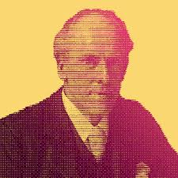

Karl Pearson

Then in 1894, probability and biology teamed up, thanks to the ultimate coin-flipping champ, Karl Pearson. Together, they created biometrics (yes, the same kind of stuff used for fingerprints and face recognition today). Pearson also made a power move by using standard deviation as a way to measure probability. This guy wasn’t just flipping coins—he was flipping the script on how we understand data!

## Enter the Russian

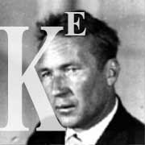

Things got real when Andrey Kolmogorov showed up. In 1933, he basically laid down the law with his standard probability axioms, which are still the foundation of modern probability theory. This was a total game-changer, and these axioms? They’re still central to everything from math to the physical sciences—and even how we handle real-world probability problems today.

The whole article has no math symbols so why not share the axioms here?

### Kolmogorov axioms

The assumptions as to setting up the axioms can be summarised as follows: Let $(\Omega ,F,P)$ be a measure space with $P(E)$ being the probability of some event $E$, and $P(\Omega )=1$. Then $(\Omega ,F,P)$ is a probability space, with sample space $\Omega$, event space $F$ and probability measure $P$.

*First axiom* - The probability of an event is a non-negative real number: $P(E)\in \mathbb {R}$, $P(E)\geq0\qquad\forall E\in F$ where $F$ is the event space. It follows (when combined with the second axiom) that $P(E)$ is always finite, in contrast with more general measure theory. Theories which assign negative probability relax the first axiom.

*Second axiom* - This is the assumption of unit measure: that the probability that at least one of the elementary events in the entire sample space will occur is 1.
$$P(\Omega
)=1$$
*Third axiom* - This is the assumption of σ-additivity: Any countable sequence of disjoint sets (synonymous with mutually exclusive events) $E_{1},E_{2},\ldots$ satisfies
$${P}\left(\bigcup_{i=1}^{\infty}{A_{i}}\right)=\sum_{i=1}^{\infty}{P(A_i)}$$
Some authors consider merely finitely additive probability spaces, in which case one just needs an algebra of sets, rather than a σ-algebra.

## So That’s it?

Not really, i missed out many more important figures, and probably a lot of more history is there which i ignored.Also a common name which is associated with probability yet i didn’t mention is Bayes, and the reason for that is most of these people worked on Classical Probability which is what we learn for most of our introductory part. Please let me know if this was an awful reasoning to leave him out. You know, It’s wild to think about how slowly mathematical discoveries spread back in the 17th century. Nowadays, a mathematician or physicist can drop their research online and instantly get feedback from a global squad of fellow researchers. But back then? Sharing ideas meant face-to-face chats, writing letters, or printing books. A “conversation” about a new finding could take months to unfold. So maybe let’s use this oppurtunity, if you have some ideas please let me know how i can improve this article.

## References

[1] Debnath, L., & Basu, K. (2014). A short history of probability theory and its applications. International Journal of Mathematical Education in Science and Technology, 46(1), 13–39. https://doi.org/10.1080/0020739x.2014.936975

[2]Devlin, K. (2010). The Pascal-Fermat Correspondence: How Mathematics Is Really Done. The Mathematics Teacher, 103(8), 578–582

[3]Hald, A. (1990). A History of Probability and Statistics and Their Applications before 1750. New York, NY: J. Wiley and Sons.

[4]Jardine, D. (2000). MATH ROOTS: Looking at Probability THROUGH A Historical Lense.

[5]Willful Ignorance, Herbert Weisberg, Wiley;

[6]Games, Gods & Gambling, F.N. David

[7] Pascal fermat Correspondence http://www.york.ac.uk/depts/maths/histstat/pascal.pdf